# Dublin Data Science Workshop on Time Series Analysis

### 3.2.3 Percentage Changes

We look at the lineplot of the percentage changes next.

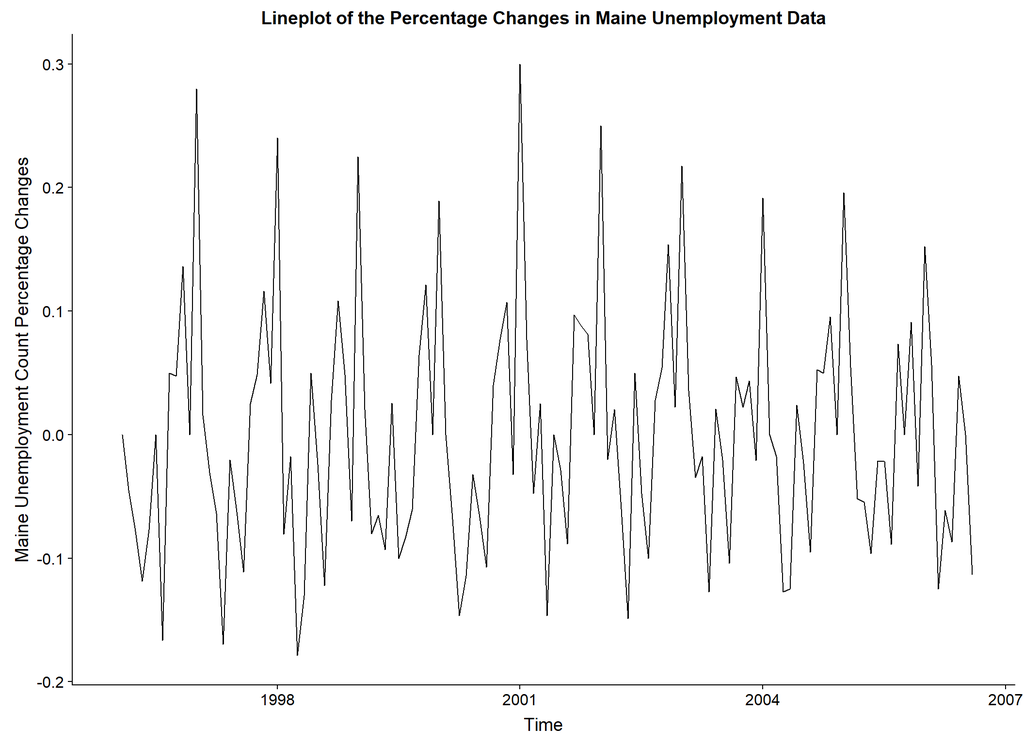

```r
ggplot(maine_explore_tbl) +
    geom_line(aes(x = month, y = perc_change)) +
    expand_limits(y = 0) +
    xlab('Time') +
    ylab('Maine Unemployment Count Percentage Changes') +
    ggtitle('Lineplot of the Percentage Changes in Maine Unemployment Data')
```

We now look for seasonal patterns in the percentage changes.

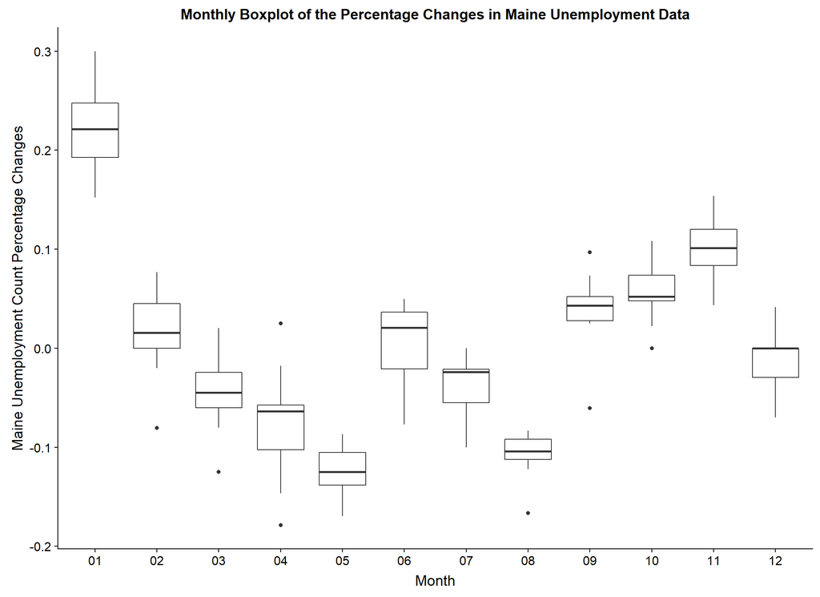

```r
ggplot(maine_explore_tbl) +
    geom_boxplot(aes(x = cal_month, y = perc_change)) +
    expand_limits(y = 0) +
    xlab('Month') +
    ylab('Maine Unemployment Count Percentage Changes') +
    ggtitle('Monthly Boxplot of the Percentage Changes in Maine Unemployment Data')
```

# 4 Time Series Decomposition

Many time series are dominated by trends or seasonal effects, and we can create fairly simple models based on these two components. The first of these, the *additive decompositional model*, is just the sum of these effects, with the residual component being treated as random:

$$x_t = m_t + s_t + z_t,$$

where, at any given time $t$,

$$\begin{eqnarray*}
x_t && \text{is the observed value} \\
m_t && \text{is the trend} \\
s_t && \text{is the seasonal component} \\
z_t && \text{is the error term}
\end{eqnarray*}$$

It is worth noting that, in general, the error terms will be a correlated sequence of values, something we will account for and model later.

In other cases, we could have a situation where the seasonal effect increases as the trend increases, modeling the values as:

$$x_t = m_t s_t + z_t.$$

Other options also exist, such as modeling the log of the observed values, which does cause some non-trivial modeling issues, such as biasing any predicted values for the time series.

Various methods are used for estimating the trend, such as taking a *moving average* of the values, which is a common approach.

## 4.1 Simple Decomposition

We start with the simplest decomposition: the simple additive model with a moving average trend.

### 4.1.1 Additive Models

The `decompose` function in R allows us to build this:

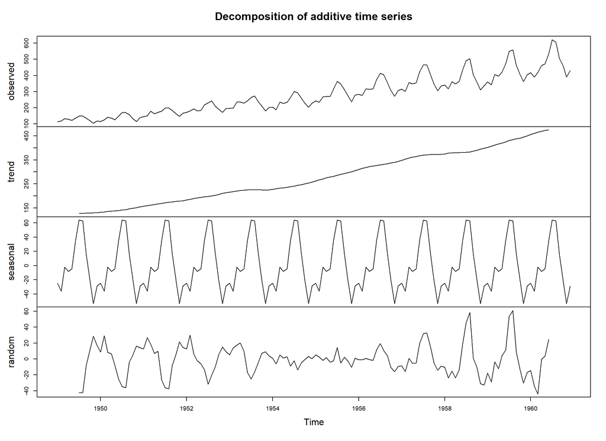

```r
ap_ts_sa_decompose <- airpassengers_tbl %>%
    tk_ts(select = value, start = 1949, frequency = 12) %>%
    decompose()

ap_ts_sa_decompose %>% plot()
```

The package `sweep` provides us with a number of routines to help us tidy the output of these routines.

```r
ap_ts_sa_decompose_tbl <- ap_ts_sa_decompose %>%
    sw_tidy_decomp(rename_index = 'month')


ap_ts_sa_decompose_tbl %>% glimpse()
```

```
## Observations: 144
## Variables: 6
## $ month    <S3: yearmon> Jan 1949, Feb 1949, Mar 1949, Apr 1949, May 1949, ...
## $ observed <dbl> 112, 118, 132, 129, 121, 135, 148, 148, 136, 119, 104, 118...
## $ season   <dbl> -24.74874, -36.18813, -2.24116, -8.03662, -4.50631, 35.402...
## $ trend    <dbl> NA, NA, NA, NA, NA, NA, 126.792, 127.250, 127.958, 128.583...
## $ random   <dbl> NA, NA, NA, NA, NA, NA, -42.62247, -42.07323, -8.47854, 11...
## $ seasadj  <dbl> 136.7487, 154.1881, 134.2412, 137.0366, 125.5063, 99.5972,...
```

```r
ap_ts_sa_decompose_tbl %>% print()
```

```
## # A tibble: 144 x 6
##    month         observed season trend random seasadj
##    <S3: yearmon>    <dbl>  <dbl> <dbl>  <dbl>   <dbl>
##  1 Jan 1949           112 -24.7    NA   NA      137.
##  2 Feb 1949           118 -36.2    NA   NA      154.
##  3 Mar 1949           132  -2.24   NA   NA      134.
##  4 Apr 1949           129  -8.04   NA   NA      137.
##  5 May 1949           121  -4.51   NA   NA      126.
##  6 Jun 1949           135  35.4    NA   NA       99.6
##  7 Jul 1949           148  63.8   127. -42.6     84.2
##  8 Aug 1949           148  62.8   127. -42.1     85.2
##  9 Sep 1949           136  16.5   128.  -8.48   119.
## 10 Oct 1949           119 -20.6   129.  11.1    140.
## # ... with 134 more rows
```

We have decomposed the time series into components, and the `sw_tidy_decomp()` function calculates the ‘seasonally adjusted’ values of the trend i.e. the ‘underlying’ value ignoring seasonality.

Comparing the observed and seasonally adjusted values are straight-forward from this, we plot both together.

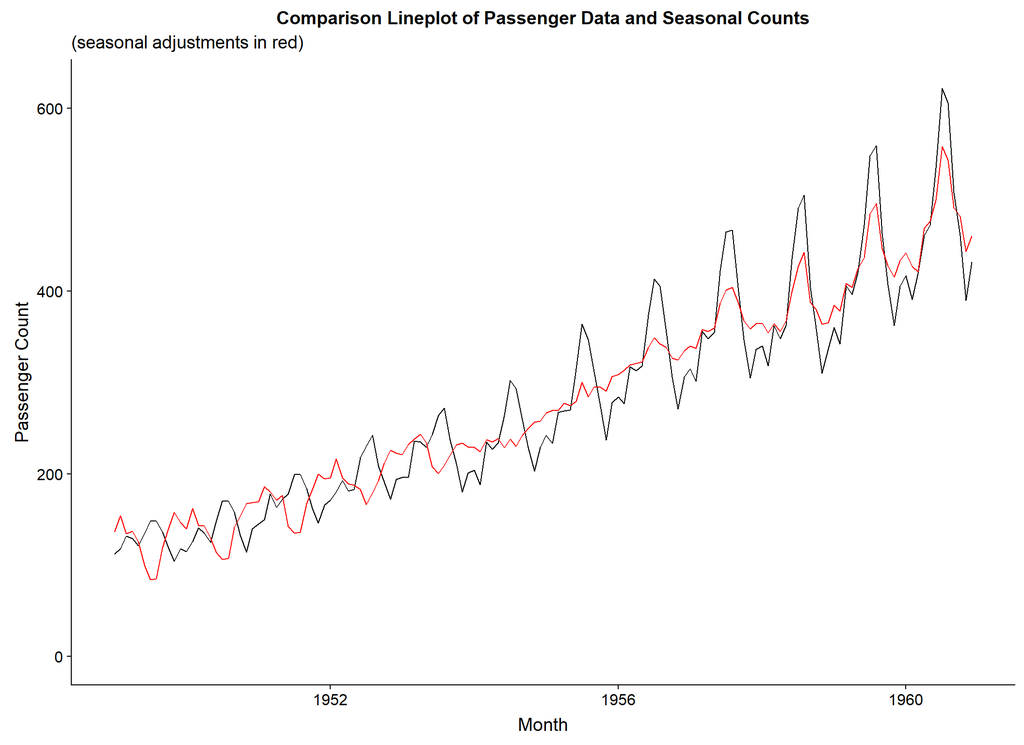

```r
ggplot(ap_ts_sa_decompose_tbl) +
    geom_line(aes(x = month, y = observed)) +
    geom_line(aes(x = month, y = seasadj), colour = 'red') +
    expand_limits(y = 0) +
    xlab('Month') +
    ylab('Passenger Count') +
    ggtitle('Comparison Lineplot of Passenger Data and Seasonal Counts'
           ,subtitle = '(seasonal adjustments in red)')
```

We now want to plot this data, and the easiest way to do this is to convert it to ‘long’ format and plot each quantity separately.

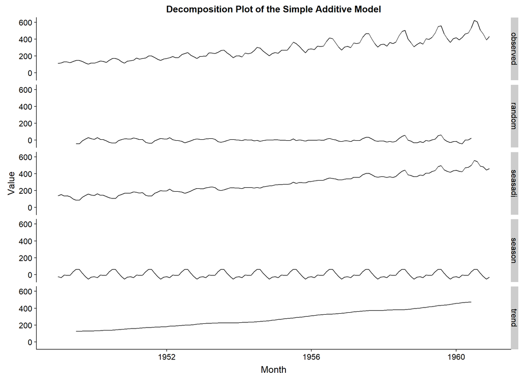

```r
plot_tbl <- ap_ts_sa_decompose_tbl %>%
    gather('label', 'value', -month)

ggplot(plot_tbl) +
    geom_line(aes(x = month, y = value)) +
    facet_grid(rows = vars(label)) +
    expand_limits(y = 0) +
    xlab('Month') +
    ylab('Value') +
    ggtitle('Decomposition Plot of the Simple Additive Model')
```

Due to the difference in scales for each parameter, we redo this plot but we free up the $y$-axis scale.

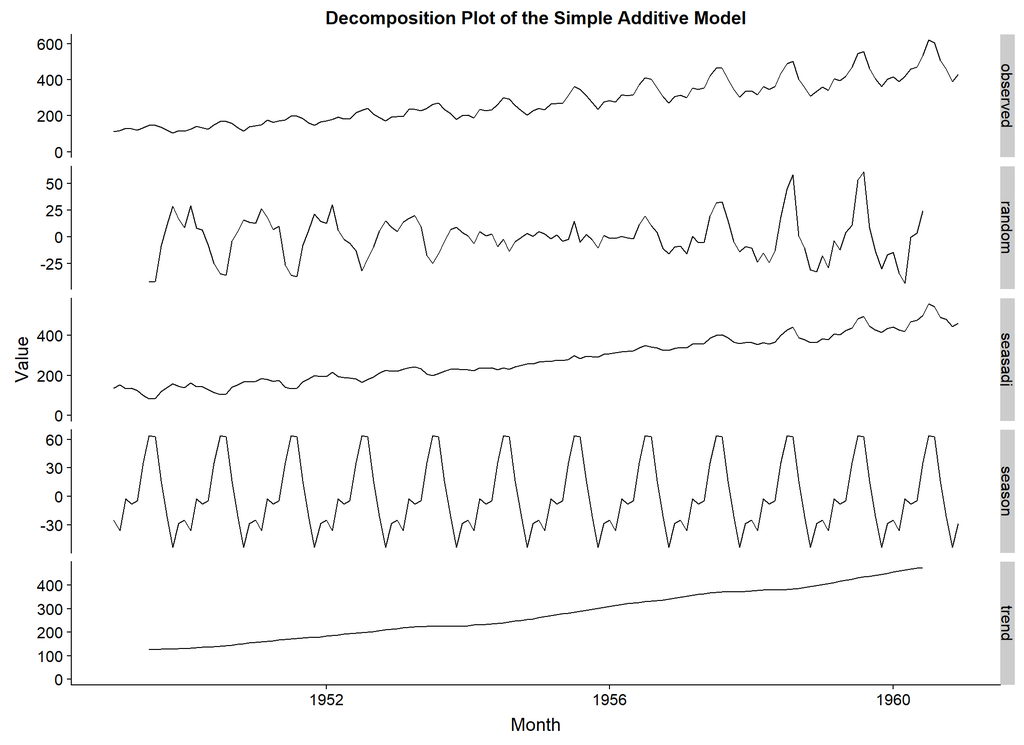

```r
ggplot(plot_tbl) +
    geom_line(aes(x = month, y = value)) +
    facet_grid(rows = vars(label), scales = 'free_y') +
    expand_limits(y = 0) +
    xlab('Month') +
    ylab('Value') +
    ggtitle('Decomposition Plot of the Simple Additive Model')
```

#### 4.1.1.1 Exercises

1. Construct the simple additive decomposition on the Maine unemployment data.
2. Construct the simple additive decomposition on the Australian CBE data.

### 4.1.2 Multiplicative Models

Constructing the multiplicative decomposition model is similar, but this time the seasonal component and error are multiplied to the trend rather than added.

Other than this, the multiplicative model works in a similar fashion. Once again, while we focus on creating plots using `ggplot2` we will use the default plotting system as a quick check.

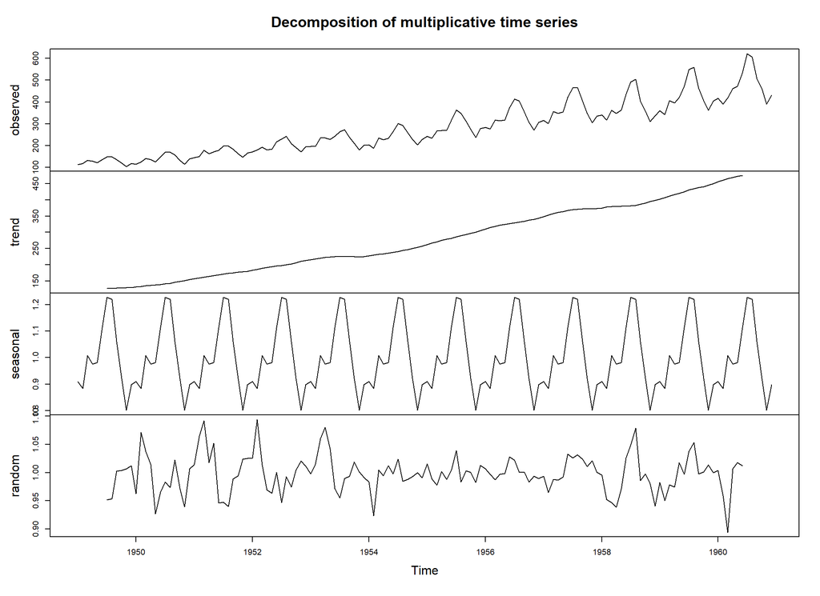

```r
ap_ts_sm_decompose <- airpassengers_tbl %>%
    tk_ts(select = value, start = 1949, frequency = 12) %>%
    decompose(type = 'multiplicative')

ap_ts_sm_decompose %>% plot()
```

Having created the decomposition object, we now inspect the outputs and produce plots.

```r
ap_ts_sm_decompose_tbl <- ap_ts_sm_decompose %>%
    sw_tidy_decomp(rename_index = 'month')

ap_ts_sm_decompose_tbl %>% glimpse()
```

```
## Observations: 144
## Variables: 6
## $ month    <S3: yearmon> Jan 1949, Feb 1949, Mar 1949, Apr 1949, May 1949, ...
## $ observed <dbl> 112, 118, 132, 129, 121, 135, 148, 148, 136, 119, 104, 118...
## $ season   <dbl> 0.910230, 0.883625, 1.007366, 0.975906, 0.981378, 1.112776...
## $ trend    <dbl> NA, NA, NA, NA, NA, NA, 126.792, 127.250, 127.958, 128.583...
## $ random   <dbl> NA, NA, NA, NA, NA, NA, 0.951664, 0.953401, 1.002220, 1.00...
## $ seasadj  <dbl> 123.046, 133.541, 131.035, 132.185, 123.296, 121.318, 120....
```

```r
ap_ts_sm_decompose_tbl %>% print()
```

```
## # A tibble: 144 x 6
##    month         observed season trend random seasadj
##    <S3: yearmon>    <dbl>  <dbl> <dbl>  <dbl>   <dbl>
##  1 Jan 1949           112  0.910   NA  NA        123.
##  2 Feb 1949           118  0.884   NA  NA        134.
##  3 Mar 1949           132  1.01    NA  NA        131.
##  4 Apr 1949           129  0.976   NA  NA        132.
##  5 May 1949           121  0.981   NA  NA        123.
##  6 Jun 1949           135  1.11    NA  NA        121.
##  7 Jul 1949           148  1.23   127.  0.952    121.
##  8 Aug 1949           148  1.22   127.  0.953    121.
##  9 Sep 1949           136  1.06   128.  1.00     128.
## 10 Oct 1949           119  0.922  129.  1.00     129.
## # ... with 134 more rows
```

While the model is different from before, it produces similar outputs, and so our plot code is almost identical to before.

We compare the observed values to the seasonally-adjusted ones first via a lineplot.

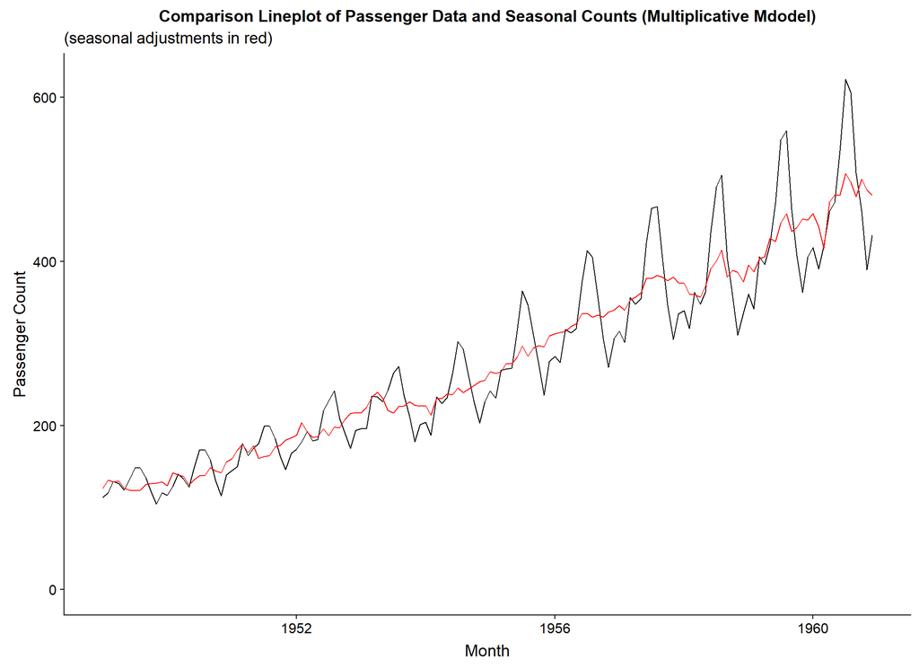

```r
ggplot(ap_ts_sm_decompose_tbl) +
    geom_line(aes(x = month, y = observed)) +
    geom_line(aes(x = month, y = seasadj), colour = 'red') +
    expand_limits(y = 0) +
    xlab('Month') +
    ylab('Passenger Count') +
    ggtitle('Comparison Lineplot of Passenger Data and Seasonal Counts (Multiplicative Mdodel)'
           ,subtitle = '(seasonal adjustments in red)')
```

We then look at the full decomposition plot, and each of the components.

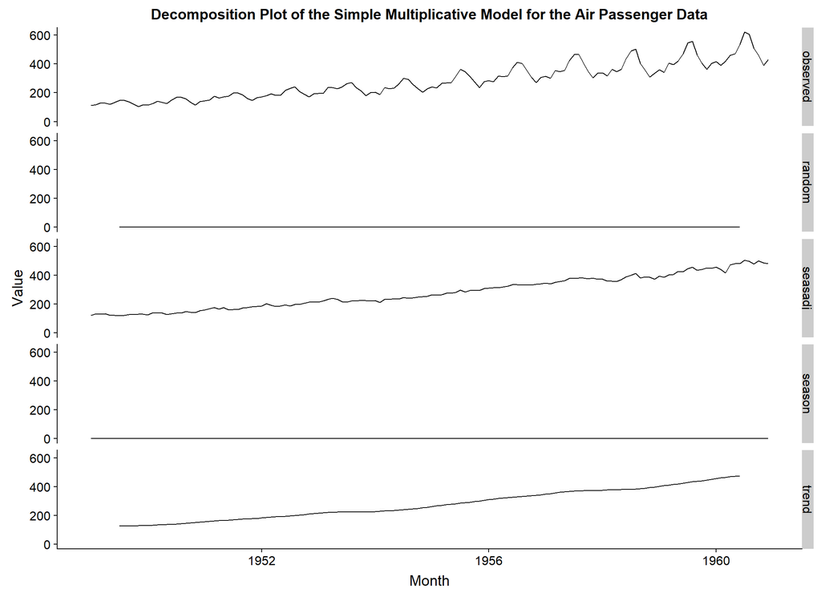

```r
plot_tbl <- ap_ts_sm_decompose_tbl %>%
    gather('label', 'value', -month)

ggplot(plot_tbl) +
    geom_line(aes(x = month, y = value)) +
    facet_grid(rows = vars(label)) +
    expand_limits(y = 0) +
    xlab('Month') +
    ylab('Value') +
    ggtitle('Decomposition Plot of the Simple Multiplicative Model for the Air Passenger Data')
```

Like for the additive model, the components of the decomposition are on different scales, so we redo the plot with a free $y$-axis.

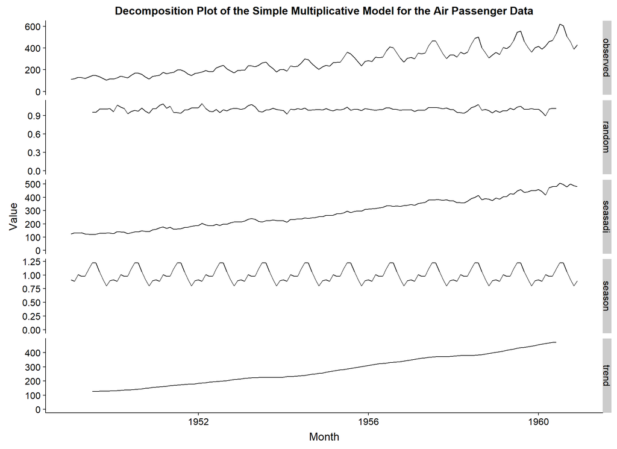

```r
ggplot(plot_tbl) +
    geom_line(aes(x = month, y = value)) +
    facet_grid(rows = vars(label), scales = 'free_y') +
    expand_limits(y = 0) +
    xlab('Month') +
    ylab('Value') +
    ggtitle('Decomposition Plot of the Simple Multiplicative Model for the Air Passenger Data')
```

#### 4.1.2.1 Exercises

1. Construct the simple multiplicative decomposition on the Maine unemployment data.
2. Construct the simple multiplicative decomposition on the Australian CBE data.

### 4.1.3 Drawbacks of Decomposition

The above approach for time-series decomposition have the benefit of simplicity both in terms of intuition and calculation, but come with a number of drawbacks:

- Estimates of the trend are not available at the start and end of the time-series.
- The trend-cycle estimate tends to over-smooth rapid rises and falls in the data - we can check for this by inspecting the remainder.
- Seasonal components are fixed throughout the dataset and do not change - an assumption much too simplistic for real-world data, especially those collected over long periods of time
- Idiosyncratic events causing short-term changes in behaviour are not managed well

## 4.2 STL Decomposition

The estimation of trend in a time series is often referred to as *smoothing* as it tries to remove higher frequency noise in the signal to understand the underlying signal.

These smoothing procedures often use data points both before and after the time at which the smoothed estimate is to calculated. This makes it useless for direct forecasting, but nevertheless can reveal interesting structure in the data.

Previously we looked at using moving averages to estimate the trend, but an alternative approach is to use *Seasonal and Trend decomposition using Loess* or STL. This estimates the trend by using locally-weighted regression (loess) methods.

### 4.2.1 Periodic STL

Our first use of STL involves using a regression window equal to the size of the period of the data. For `AirPassengers`, this is 12, but we do not have to set this explicitly.

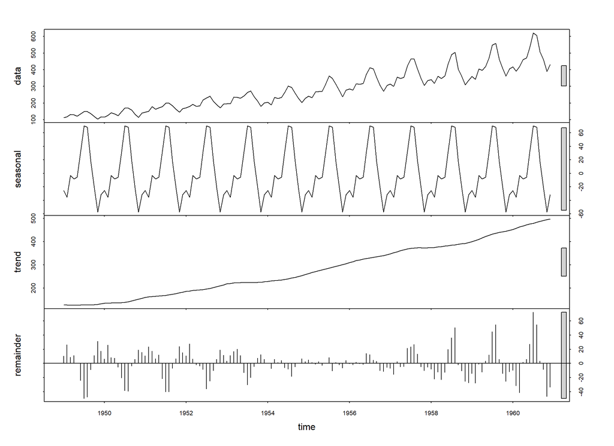

```r
ap_stl_decompose <- airpassengers_tbl %>%
    tk_ts(select = value, start = 1949, frequency = 12) %>%
    magrittr::extract(,1) %>%       # need to use this for compatibility with stl()
    stl(s.window = 'periodic')

ap_stl_decompose %>% plot()
```

As before, we can use functions in the `sweep` package to create tidy outputs to ease plotting and analysis.

```r
ap_stl_decompose_tbl <- ap_stl_decompose %>%
    sw_tidy_decomp(rename_index = 'month')

ap_stl_decompose_tbl %>% glimpse()
```

```
## Observations: 144
## Variables: 6
## $ month     <S3: yearmon> Jan 1949, Feb 1949, Mar 1949, Apr 1949, May 1949,...
## $ observed  <dbl> 112, 118, 132, 129, 121, 135, 148, 148, 136, 119, 104, 11...
## $ season    <dbl> -25.49772, -35.22093, -3.02748, -8.29905, -5.73729, 32.33...
## $ trend     <dbl> 127.187, 126.650, 126.112, 126.199, 126.286, 126.733, 127...
## $ remainder <dbl> 10.310370, 26.571403, 8.915762, 11.100122, 0.451141, -24....
## $ seasadj   <dbl> 137.4977, 153.2209, 135.0275, 137.2991, 126.7373, 102.663...
```

```r
ap_stl_decompose_tbl %>% print()
```

```
## # A tibble: 144 x 6
##    month         observed season trend remainder seasadj
##    <S3: yearmon>    <dbl>  <dbl> <dbl>     <dbl>   <dbl>
##  1 Jan 1949          112. -25.5   127.    10.3     137.
##  2 Feb 1949          118  -35.2   127.    26.6     153.
##  3 Mar 1949          132   -3.03  126.     8.92    135.
##  4 Apr 1949          129   -8.30  126.    11.1     137.
##  5 May 1949          121   -5.74  126.     0.451   127.
##  6 Jun 1949          135   32.3   127.   -24.1     103.
##  7 Jul 1949          148   70.2   127.   -49.4      77.8
##  8 Aug 1949          148   68.0   127.   -47.5      80.0
##  9 Sep 1949          136   17.4   128.    -9.09    119.
## 10 Oct 1949          119. -21.1   129.    11.0     140.
## # ... with 134 more rows
```

This decomposition seems similar to the one produced by the `decompose()` function, so we should compare the output. This is where tidy output is useful: we use standard `dplyr` and `tidyr` methodologies to manipulate the data and produce plots for visual inspection.

```r
decomp_tbl <- ap_ts_sa_decompose_tbl %>%
    rename(remainder = random)

stl_tbl <- ap_stl_decompose_tbl


decomp_compare_tbl <- list(
    `Simple Additive` = decomp_tbl
   ,`STL Periodic`    = stl_tbl
    ) %>%
    bind_rows(.id = 'category')

decomp_compare_tbl %>% glimpse()
```

```
## Observations: 288
## Variables: 7
## $ category  <chr> "Simple Additive", "Simple Additive", "Simple Additive", ...
## $ month     <dbl> 1949.00, 1949.08, 1949.17, 1949.25, 1949.33, 1949.42, 194...
## $ observed  <dbl> 112, 118, 132, 129, 121, 135, 148, 148, 136, 119, 104, 11...
## $ season    <dbl> -24.74874, -36.18813, -2.24116, -8.03662, -4.50631, 35.40...
## $ trend     <dbl> NA, NA, NA, NA, NA, NA, 126.792, 127.250, 127.958, 128.58...
## $ remainder <dbl> NA, NA, NA, NA, NA, NA, -42.62247, -42.07323, -8.47854, 1...
## $ seasadj   <dbl> 136.7487, 154.1881, 134.2412, 137.0366, 125.5063, 99.5972...
```

```r
decomp_compare_tbl %>% print()
```

```
## # A tibble: 288 x 7
##    category        month observed season trend remainder seasadj
##    <chr>           <dbl>    <dbl>  <dbl> <dbl>     <dbl>   <dbl>
##  1 Simple Additive 1949       112 -24.7    NA      NA      137.
##  2 Simple Additive 1949.      118 -36.2    NA      NA      154.
##  3 Simple Additive 1949.      132  -2.24   NA      NA      134.
##  4 Simple Additive 1949.      129  -8.04   NA      NA      137.
##  5 Simple Additive 1949.      121  -4.51   NA      NA      126.
##  6 Simple Additive 1949.      135  35.4    NA      NA       99.6
##  7 Simple Additive 1950.      148  63.8   127.    -42.6     84.2
##  8 Simple Additive 1950.      148  62.8   127.    -42.1     85.2
##  9 Simple Additive 1950.      136  16.5   128.     -8.48   119.
## 10 Simple Additive 1950.      119 -20.6   129.     11.1    140.
## # ... with 278 more rows
```

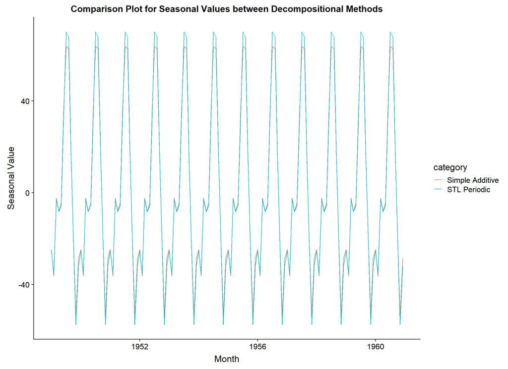

```r
ggplot(decomp_compare_tbl) +
    geom_line(aes(x = month, y = season, colour = category)) +
    expand_limits(y = 0) +
    xlab('Month') +
    ylab('Seasonal Value') +
    ggtitle('Comparison Plot for Seasonal Values between Decompositional Methods')
```

Seasonal values are almost the same, so we now compare trend values.

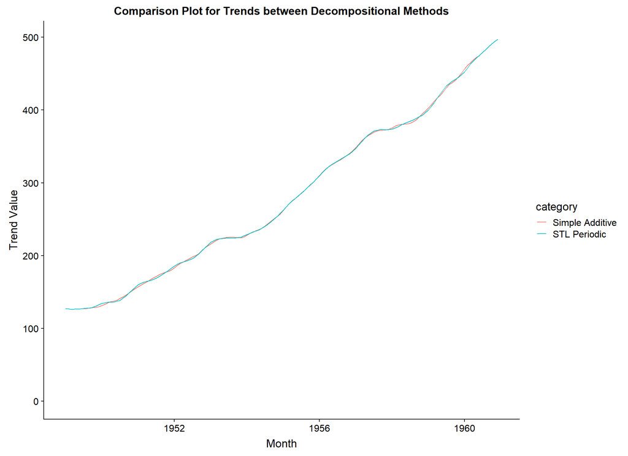

```r
ggplot(decomp_compare_tbl) +
    geom_line(aes(x = month, y = trend, colour = category)) +
    expand_limits(y = 0) +
    xlab('Month') +
    ylab('Trend Value') +
    ggtitle('Comparison Plot for Trends between Decompositional Methods')
```

We see here that the STL with Periodic smoothing window is almost the same as the standard `decompose()` function for the Air Passenger data.

### 4.2.2 Robust STL

We can also use robust loess to perform the STL, and compare the results.

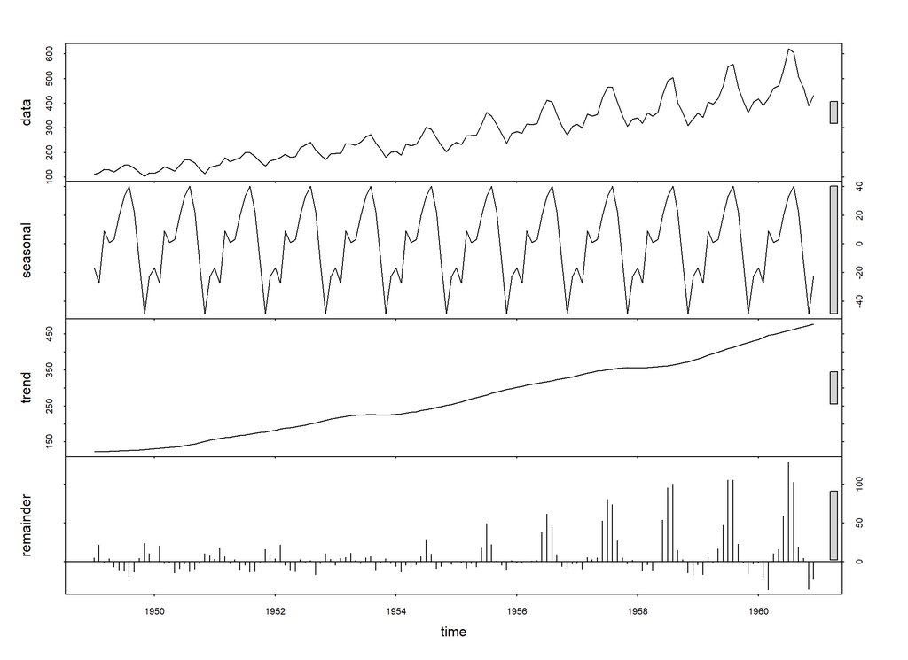

```r
ap_stl_robust_decompose <- airpassengers_tbl %>%
    tk_ts(select = value, start = 1949, frequency = 12) %>%
    magrittr::extract(,1) %>%       # need to use this for compatibility with stl()
    stl(s.window = 'periodic', robust = TRUE)

ap_stl_robust_decompose %>% plot()
```

As before, we can use functions in the `sweep` package to create tidy outputs to ease plotting and analysis.

```r
ap_stl_robust_decompose_tbl <- ap_stl_robust_decompose %>%
    sw_tidy_decomp(rename_index = 'month')

ap_stl_robust_decompose_tbl %>% glimpse()
```

```
## Observations: 144
## Variables: 6
## $ month     <S3: yearmon> Jan 1949, Feb 1949, Mar 1949, Apr 1949, May 1949,...
## $ observed  <dbl> 112, 118, 132, 129, 121, 135, 148, 148, 136, 119, 104, 11...
## $ season    <dbl> -16.519819, -27.337882, 9.009778, 0.992387, 3.081231, 20....
## $ trend     <dbl> 123.186, 123.421, 123.657, 124.137, 124.616, 125.216, 125...
## $ remainder <dbl> 5.3341624, 21.9164399, -0.6670047, 3.8711054, -6.6970183,...
## $ seasadj   <dbl> 128.520, 145.338, 122.990, 128.008, 117.919, 114.997, 114...
```

```r
ap_stl_robust_decompose_tbl %>% print()
```

```
## # A tibble: 144 x 6
##    month         observed  season trend remainder seasadj
##    <S3: yearmon>    <dbl>   <dbl> <dbl>     <dbl>   <dbl>
##  1 Jan 1949          112  -16.5    123.     5.33     129.
##  2 Feb 1949          118. -27.3    123.    21.9      145.
##  3 Mar 1949          132    9.01   124.    -0.667    123.
##  4 Apr 1949          129    0.992  124.     3.87     128.
##  5 May 1949          121    3.08   125.    -6.70     118.
##  6 Jun 1949          135   20.0    125.   -10.2      115.
##  7 Jul 1949          148   33.4    126.   -11.2      115.
##  8 Aug 1949          148   40.1    126.   -18.4      108.
##  9 Sep 1949          136   22.2    127.   -13.1      114.
## 10 Oct 1949          119. -13.6    128.     4.82     133.
## # ... with 134 more rows
```

### 4.2.3 Decomposition Comparisons

We now directly compare all the decompositions.

```r
decomp_compare_tbl <- list(
    `Simple Additive` = decomp_tbl
   ,`STL Periodic`    = stl_tbl
   ,`STL Robust`      = ap_stl_robust_decompose_tbl
    ) %>%
    bind_rows(.id = 'category')

decomp_compare_tbl %>% glimpse()
```

```
## Observations: 432
## Variables: 7
## $ category  <chr> "Simple Additive", "Simple Additive", "Simple Additive", ...
## $ month     <dbl> 1949.00, 1949.08, 1949.17, 1949.25, 1949.33, 1949.42, 194...
## $ observed  <dbl> 112, 118, 132, 129, 121, 135, 148, 148, 136, 119, 104, 11...
## $ season    <dbl> -24.74874, -36.18813, -2.24116, -8.03662, -4.50631, 35.40...
## $ trend     <dbl> NA, NA, NA, NA, NA, NA, 126.792, 127.250, 127.958, 128.58...
## $ remainder <dbl> NA, NA, NA, NA, NA, NA, -42.62247, -42.07323, -8.47854, 1...
## $ seasadj   <dbl> 136.7487, 154.1881, 134.2412, 137.0366, 125.5063, 99.5972...
```

```r
decomp_compare_tbl %>% print()
```

```
## # A tibble: 432 x 7
##    category        month observed season trend remainder seasadj
##    <chr>           <dbl>    <dbl>  <dbl> <dbl>     <dbl>   <dbl>
##  1 Simple Additive 1949       112 -24.7    NA      NA      137.
##  2 Simple Additive 1949.      118 -36.2    NA      NA      154.
##  3 Simple Additive 1949.      132  -2.24   NA      NA      134.
##  4 Simple Additive 1949.      129  -8.04   NA      NA      137.
##  5 Simple Additive 1949.      121  -4.51   NA      NA      126.
##  6 Simple Additive 1949.      135  35.4    NA      NA       99.6
##  7 Simple Additive 1950.      148  63.8   127.    -42.6     84.2
##  8 Simple Additive 1950.      148  62.8   127.    -42.1     85.2
##  9 Simple Additive 1950.      136  16.5   128.     -8.48   119.
## 10 Simple Additive 1950.      119 -20.6   129.     11.1    140.
## # ... with 422 more rows
```

We have constructed the comparison dataset and now plot the seasonal values for the different decompositions.

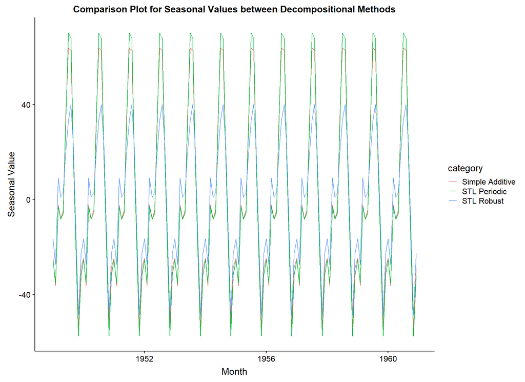

```r
ggplot(decomp_compare_tbl) +
    geom_line(aes(x = month, y = season, colour = category)) +
    expand_limits(y = 0) +
    xlab('Month') +
    ylab('Seasonal Value') +
    ggtitle('Comparison Plot for Seasonal Values between Decompositional Methods')
```

We now look at trend values for the different decompositions.

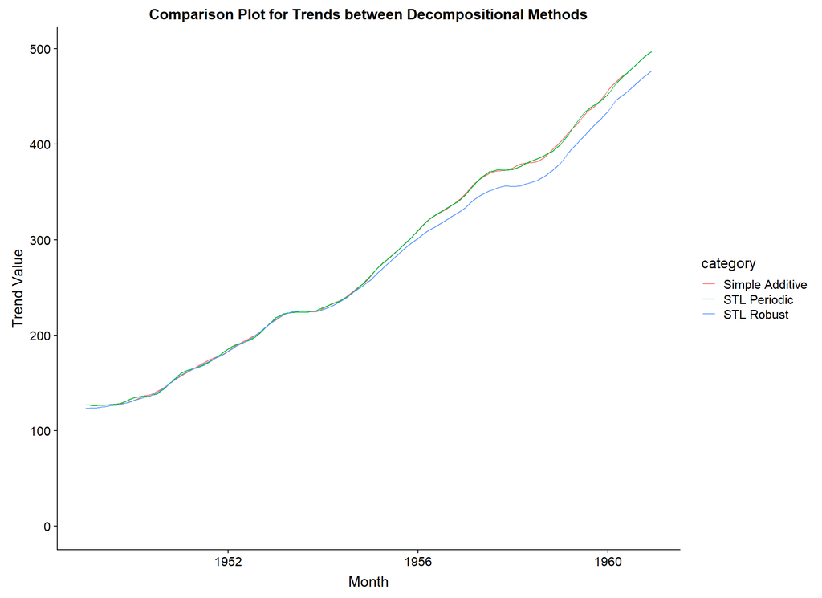

```r
ggplot(decomp_compare_tbl) +
    geom_line(aes(x = month, y = trend, colour = category)) +
    expand_limits(y = 0) +
    xlab('Month') +
    ylab('Trend Value') +
    ggtitle('Comparison Plot for Trends between Decompositional Methods')
```

## 4.3 Additional Decompositions

Many more approaches to time-series decomposition exist, but a thorough exploration of the techniques is beyond the scope of this workshop. Furthermore, while a number of excellent packages exist in R to perform this analysis, at the time of this workshop, they are not compatible with `tidyquant`.

That said, some of these are very useful, so we will introduce them and show some simple uses of them, and leave further exploration as an exercise.

### 4.3.1 X11 Decomposition

The X11 method was developed by US Census Bureau and Statistics Canada to assist them in the analysis of their statistical data collection and analysis.

Building upon the existing approaches discussed already, the approach allows for the changes in seasonal effects over time, different day counts in each month and other wrinkles such as holidays.

The `seasonal` package provides an implementation of this decomposition, and while we do not have a `tidyquant` interface for it, the `forecast` package provides some simple plotting routines.

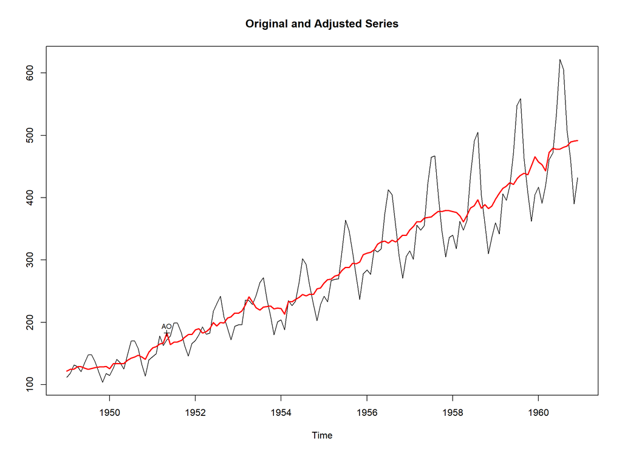

```r
ap_x11_decompose <- airpassengers_tbl %>%
    tk_ts(select = value, start = 1949, frequency = 12) %>%
    seas(x11 = '')

ap_x11_decompose %>% plot()
```

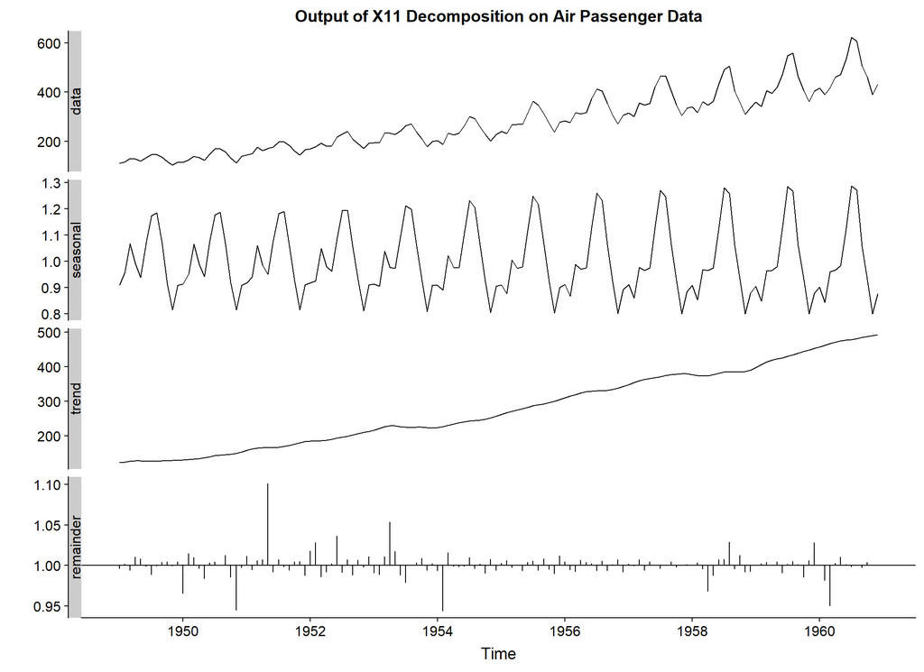

```r
ap_x11_decompose %>%
    autoplot() + ggtitle("Output of X11 Decomposition on Air Passenger Data")
```

### 4.3.2 SEATS Decomposition

“SEATS” stands for *Seasonal Extraction in ARIMA Time Series*. Developed by the Bank of Spain, this approach is commonly used by government agencies but only works with quarterly and monthly data - data with seasonal effects at other frequencies will require a different method.

As we did with X11, we will show the output for the default and leave its exploration as an exercise.

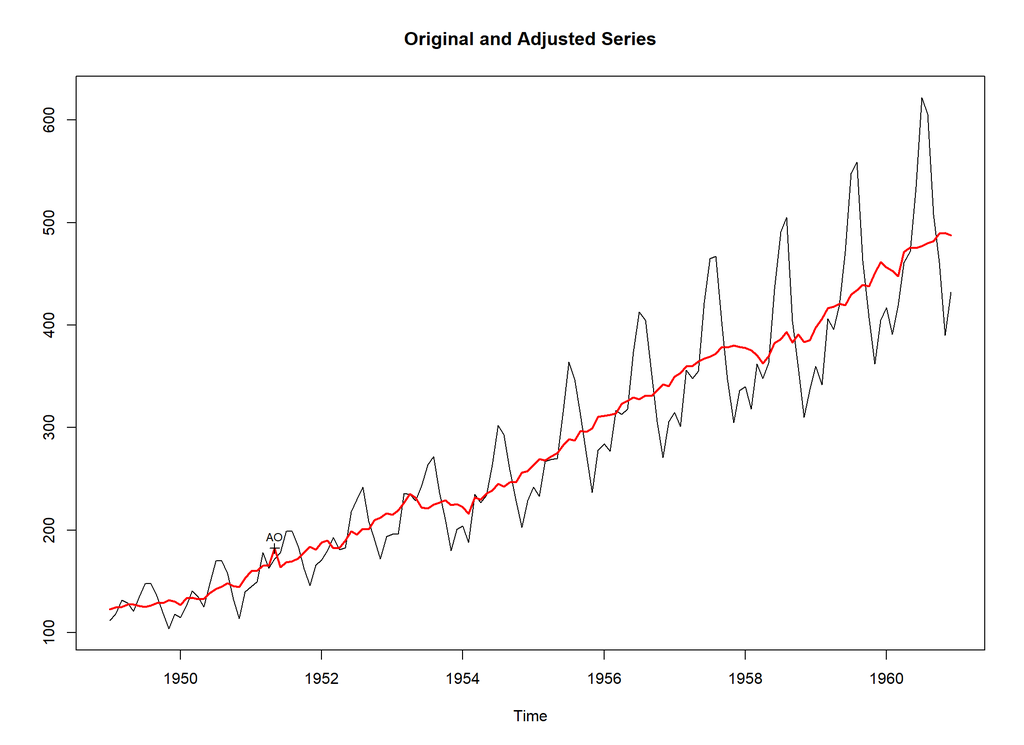

```r
ap_seats_decompose <- airpassengers_tbl %>%
    tk_ts(select = value, start = 1949, frequency = 12) %>%
    seas()

ap_seats_decompose %>% plot()
```

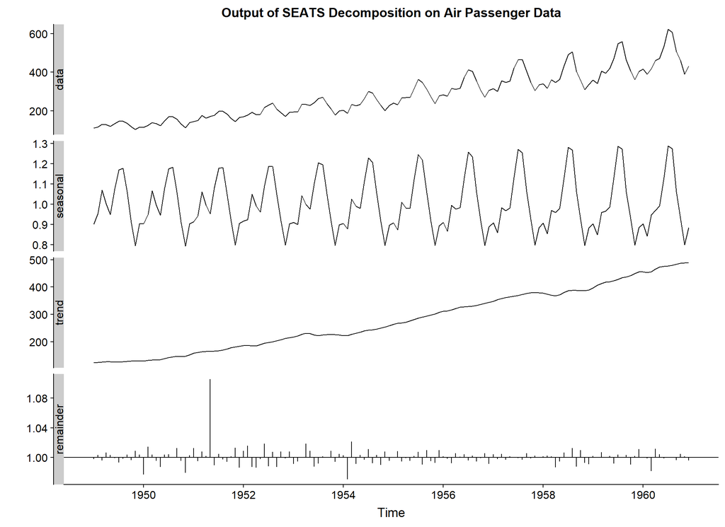

```r
ap_seats_decompose %>%
    autoplot() + ggtitle("Output of SEATS Decomposition on Air Passenger Data")
```

# 5 Time-Series Structure

Assuming we can remove the trend and the seasonal variation, we still have the random component, $z_t$. Up to now, we have modelled this random component as a sequence of random variables.

To simplify the analysis, we often make assumptions such like the random form a sequence of *independent and identically distributed (i.i.d.)* random variables, but this is rarely effective.

Most of the time, the $z_t$ are correlated and so we need to put some structure on our framework for modelling this.

To that end, we now look at some statistical concepts and quantities that are used to help with this modelling piece.

## 5.1 Random Variables

The *expected value* or *expectation* of a random variable $x$, denoted $E(x)$, is the mean value of $x$ in the population. Thus, for a continuous $x$, we have

$$\mu = E(x) = \int p(x) \, x \, dx.$$

and the *variance*, $\sigma^2$, is the expectation of the squared deviations,

$$\text{Var}(x) = \sigma^2 = E[(x - \mu)^2],$$

For bivariate data, each datapoint can be represented as $(x, y)$ and we can generalise this concept to the *covariance*, $\gamma(x, y)$,

$$\gamma(x, y) = \text{Cov}(x, y) = E[(x - \mu_x)(y - \mu_y)].$$

Correlation, $\rho$, is standardised covariance – we scale the covariance by the standard deviation of the two variables,

$$\rho(x, y) = \frac{\gamma(x, y)}{\sigma_x \sigma_y}.$$

The mean function of a time series model is

$$\mu(t) = E(x_t),$$

with the expectation being across the *ensemble* across histories of possible time series produced by this model. In general, we only have one realisation of this model, and so, without any further assumption, estimate the mean to be the measured value.

If the mean function is constant, we say that the time-series is *stationary in the mean*, and the estimate of the population mean is just the sample mean,

$$\mu = \sum^n_{t=1} x_t.$$

The variance function of a time-series model that is stationary in the mean is given by

$$\sigma^2(t) = E[(x_t - \mu)^2].$$

If we make the further assumption that the time-series is also stationary in the variance, then the population variance is just the sample variance:

$$\text{Var}(x) = \frac{\sum(x_t - \mu)^2}{n - 1}$$

### 5.1.1 Exercises

1. Are any of the time series we have analysed stationary in the mean?
2. What about first differences?
3. What about percentage changes?

## 5.2 Autocorrelation (Serial Correlation)

Autocorrelation, also known as *serial correlation*, is the correlation between random variables at different time intervals in a time series. We define the *lag*, $k$ to be a fixed discrete interval for analysis. From this, we define the *autocovariance function* and the *autocorrelation function* as functions of $k$:

$$\begin{eqnarray*}
\gamma_k &=& E[(x_t - \mu)(x_{t+k} - \mu)], \\
\rho_k &=& \frac{\gamma_k}{\sigma^2}.
\end{eqnarray*}$$

In R, the `acf()` function plots the *correlogram*, the plot of the sample autocorrelation at $\rho_k$ against the lag $k$.

### 5.2.1 Analysing the AirPassenger Data

We now turn our attention to calculating autocorrelations for a given time series, starting with the Air Passenger data.

Autocorrelations and the correlogram are one of the most important concepts and tools in all of time series analysis, so while routines do exist to perform the calculations and produce the plots, we will first go through the entire process manually to ensure we have a thorough understanding of it all.

*NOTE:* Due to internal differences in how correlations are calculated (`cor()` uses a different denominator to `acf()`) - our two methods will produce slightly different values. In all cases, the values produced by `acf()` and functions it depends on are the ones to trust.

Once we have gone through this process once, we will use the more direct procedures.

```r
ap_lags_tbl <- airpassengers_tbl %>%
    tq_mutate(
        select     = value
       ,mutate_fun = lag.xts
       ,k          = 1:24
       ,col_rename = paste0('l', 1:24)
    ) %>%
    gather('lag_k','lag_val', -month, -value) %>%
    mutate(lag_k = lag_k %>% str_replace('^l', '') %>% as.integer())

ap_lags_tbl %>% glimpse()
```

```
## Observations: 3,456
## Variables: 4
## $ month   <S3: yearmon> Jan 1949, Feb 1949, Mar 1949, Apr 1949, May 1949, J...
## $ value   <dbl> 112, 118, 132, 129, 121, 135, 148, 148, 136, 119, 104, 118,...
## $ lag_k   <int> 1, 1, 1, 1, 1, 1, 1, 1, 1, 1, 1, 1, 1, 1, 1, 1, 1, 1, 1, 1,...
## $ lag_val <dbl> NA, 112, 118, 132, 129, 121, 135, 148, 148, 136, 119, 104, ...
```

```r
ap_lags_tbl %>% print()
```

```
## # A tibble: 3,456 x 4
##    month         value lag_k lag_val
##    <S3: yearmon> <dbl> <int>   <dbl>
##  1 Jan 1949        112     1      NA
##  2 Feb 1949        118     1     112
##  3 Mar 1949        132     1     118
##  4 Apr 1949        129     1     132
##  5 May 1949        121     1     129
##  6 Jun 1949        135     1     121
##  7 Jul 1949        148     1     135
##  8 Aug 1949        148     1     148
##  9 Sep 1949        136     1     148
## 10 Oct 1949        119     1     136
## # ... with 3,446 more rows
```

To calculate the autocorrelations at various lags we group by the lag amount, calculate the correlation where we have values (we do not want to include the NA values in the calculation).

Note that even independent pairs of numbers will be likely to calculate a small amount of correlation due to sample noise. This threshold can be shown to be

$$\text{Threshold} = \frac{2}{\sqrt{N}}$$

We include these cutoff bounds in the calculation.

```r
ap_autocorrs_tbl <- ap_lags_tbl %>%
    group_by(lag_k) %>%
    summarise(
        cor          = cor(x = value, y = lag_val, use = "pairwise.complete.obs")
       ,cutoff_upper =  2 / sqrt(n())
       ,cutoff_lower = -2 / sqrt(n())
    )

ap_autocorrs_tbl %>% glimpse()
```

```
## Observations: 24
## Variables: 4
## $ lag_k        <int> 1, 2, 3, 4, 5, 6, 7, 8, 9, 10, 11, 12, 13, 14, 15, 16,...
## $ cor          <dbl> 0.960195, 0.895675, 0.837395, 0.797735, 0.785943, 0.78...
## $ cutoff_upper <dbl> 0.166667, 0.166667, 0.166667, 0.166667, 0.166667, 0.16...
## $ cutoff_lower <dbl> -0.166667, -0.166667, -0.166667, -0.166667, -0.166667,...
```

```r
ap_autocorrs_tbl %>% print()
```

```
## # A tibble: 24 x 4
##    lag_k   cor cutoff_upper cutoff_lower
##    <int> <dbl>        <dbl>        <dbl>
##  1     1 0.960        0.167       -0.167
##  2     2 0.896        0.167       -0.167
##  3     3 0.837        0.167       -0.167
##  4     4 0.798        0.167       -0.167
##  5     5 0.786        0.167       -0.167
##  6     6 0.784        0.167       -0.167
##  7     7 0.785        0.167       -0.167
##  8     8 0.792        0.167       -0.167
##  9     9 0.828        0.167       -0.167
## 10    10 0.883        0.167       -0.167
## # ... with 14 more rows
```

Now that we have the data in the appropriate form, it is straight-forward to construct a plot in `ggplot2` to visualise the data.

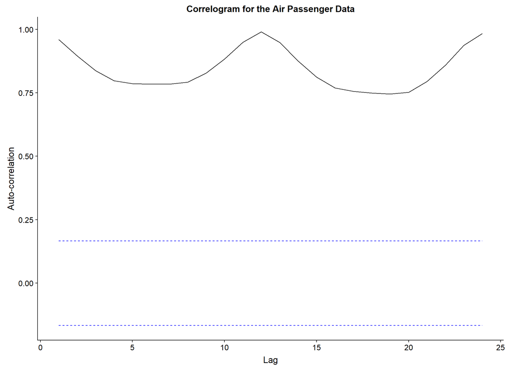

```r
ggplot(ap_autocorrs_tbl) +
    geom_line(aes(x = lag_k, y = cor)) +
    geom_line(aes(x = lag_k, y = cutoff_upper), colour = 'blue', linetype = 'dashed') +
    geom_line(aes(x = lag_k, y = cutoff_lower), colour = 'blue', linetype = 'dashed') +
    xlab('Lag') +
    ylab('Auto-correlation') +
    ggtitle('Correlogram for the Air Passenger Data')
```

As mentioned above, we can calculate these values directly in R by using `acf()` and its more user-friendly function from `forecast`, `Acf()`.

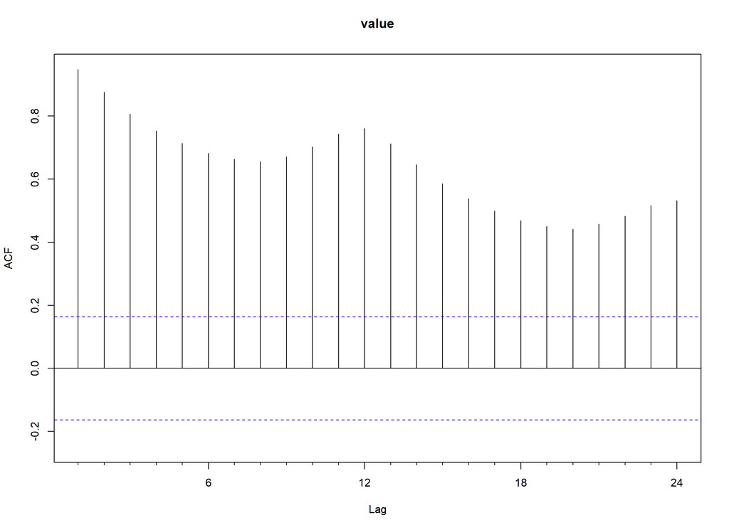

```r
ap_acf <- airpassengers_tbl %>%
    tk_ts(select = value, start = 1949, frequency = 12) %>%
    Acf()
```

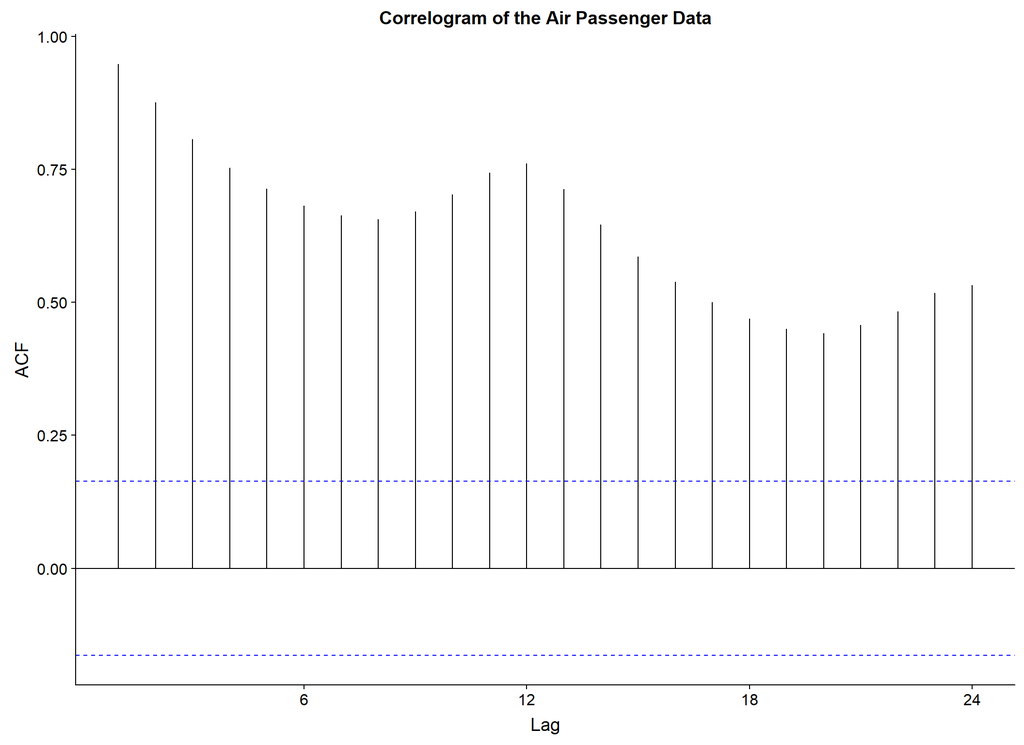

```r
ap_acf %>% autoplot() + ggtitle('Correlogram of the Air Passenger Data')
```

### 5.2.2 Partial Autocorrelation

The correlogram is useful for checking correlations lags, but due to the nature of the calculation, the autocorrelation at higher lags is related to those at lower lags.

For this reason, we often look at *partial autocorrelations* - where the correlation due to earlier lags is removed. The R code for calculating the PACF is almost identical as for the ACF.

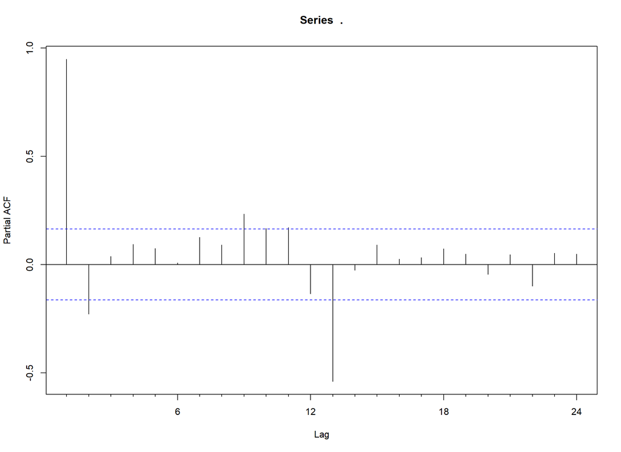

```r
ap_pacf <- airpassengers_tbl %>%
    tk_ts(select = value, start = 1949, frequency = 12) %>%
    Pacf()
```

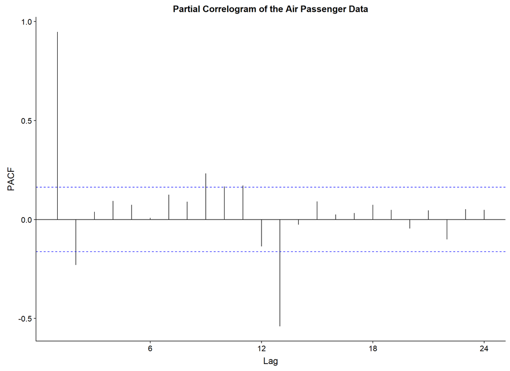

```r
ap_pacf %>% autoplot() + ggtitle('Partial Correlogram of the Air Passenger Data')
```

We see the two main correlations are at lag 1 and lag 13, manifesting the strong annual seasonality in the data.

Partial autocorrelations are especially useful for modelling autoregressive models, and we will return to this later.

## 5.3 Multivariate Covariance

Multivariate series has a temporal equivalent to correlation and covariance, known as the *cross-covariance function (ccvf)* and the *cross-correlation function (ccf)*,

$$\begin{eqnarray}
\gamma_k(x, y) &=& E[(x_{t+k} - \mu_x)(y_t - \mu_y)], \\
\rho_k(x, y) &=& \frac{\gamma_k(x, y)}{\sigma_x \sigma_y}.
\end{eqnarray}$$

Note that the above functions are not symmetric, as the lag is always on the first variable, $x$.

A corollary of this definition is that negative lags switch the order of $(x, y)$

$$\gamma_k(x, y) = \gamma_{-k}(y, x)$$

### 5.3.1 Building Activity

Before we look at the data, we might expect to have a good example of leading and lagging variables in the Australian Building data: one of the values is the number of construction approvals, the other is the amount of activity.

With this data we might expect that the behaviour in approvals will reflect later behaviour in activity - there is a natural chain of causality there.

So, we now have something to investigate, and the code functionality we know can extend to multivariate time series.

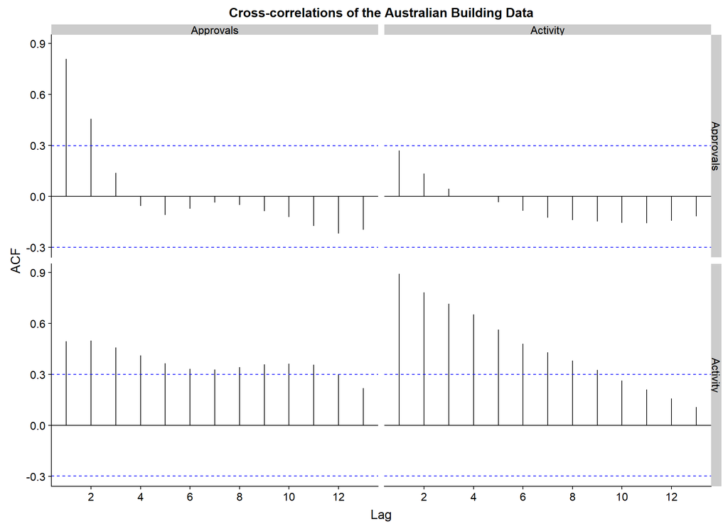

```r
approvactiv_cross_acf <- approvactiv_ts %>%
    Acf(plot = FALSE)

approvactiv_cross_acf %>%
    autoplot() +
        ggtitle('Cross-correlations of the Australian Building Data')
```

Not that these plots are not symmetric: the plots on the diagonals give us the univariate correlograms, where as plot (2,1) on the bottom left shows us the cross-correlation of approvals to activity, i.e. whether or not the approval values lead activity values.

We see quite a few lags are above the ‘noise’ threshold, indicating there is a leading effect.

The plot is the reverse: do activity values lead approval values. Here we see little evidence of this.

### 5.3.2 Cross-Correlation and Non-Stationary Series

In general, cross-correlation is defined for stationary time series as the for non-stationary series may have trends and seasonal effects, these may dominate the calculation. As a result, we typically remove trends and seasonality before looking for cross-correlations.

To illustrate this, we do a simple exercise of producing independent series with trends and seasonality and calculate cross-correlations.

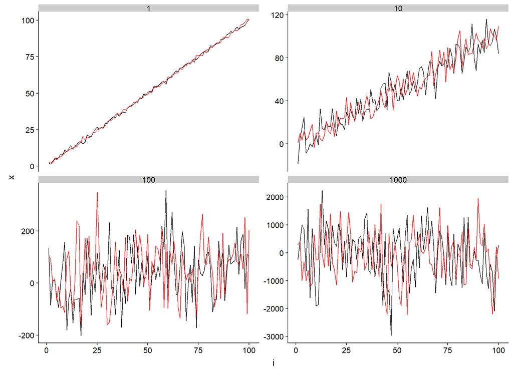

```r
produce_trend_series <- function(strength, trend = 1:100, N = 100) {
    x <- trend + strength * rnorm(N)
    y <- trend + strength * rnorm(N)

    data_tbl <- tibble(
        i = seq_along(trend)
       ,x = x
       ,y = y
    )

    return(data_tbl)
}

gen_data_tbl <- tibble(strength = c(1, 10, 100, 1000)) %>%
    mutate(data = map(strength, produce_trend_series)) %>%
    unnest()

ggplot(gen_data_tbl) +
    geom_line(aes(x = i, y = x)) +
    geom_line(aes(x = i, y = y), colour = 'red') +
    facet_wrap(~strength, ncol = 2, scale = 'free_y')
```

Having looked at the series, we see that for low values of `strength` the trend dominates the value. We now construct the cross-correlation function for each of these bivariate series.

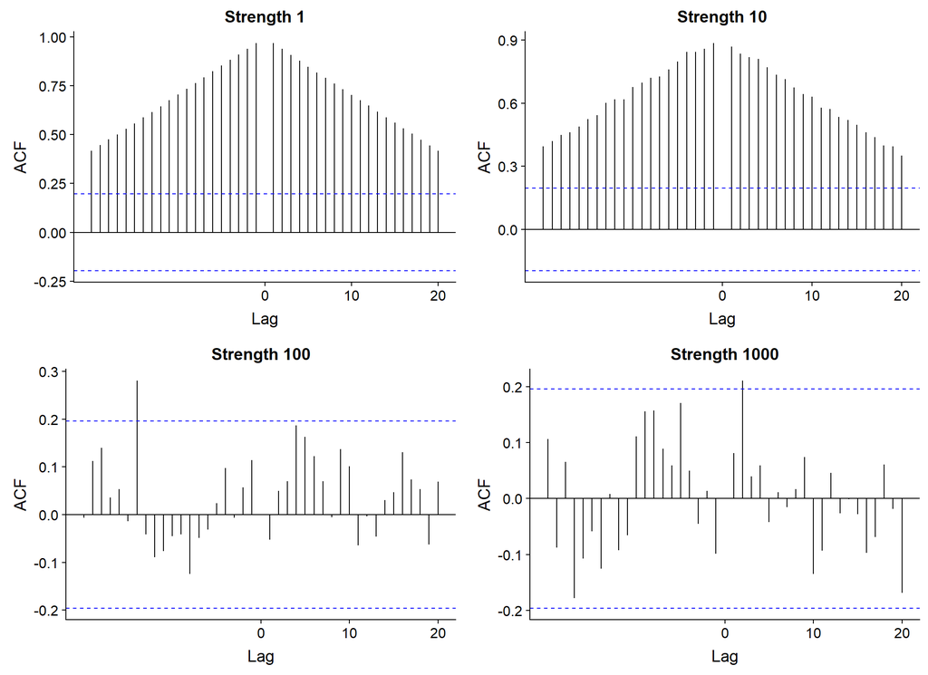

```r
create_ccf_plot <- function(ccf_data, strength) {
    autoplot(ccf_data) +
        ggtitle(paste('Strength', strength))
}

gen_data_tbl %>%
    group_by(strength) %>%
    summarise(ccf_data = list(Ccf(x, y, plot = FALSE))) %>%
    mutate(ccf_plot = map2(ccf_data, strength, create_ccf_plot)) %>%
    pull(ccf_plot) %>%
    plot_grid(plotlist = ., ncol = 2)
```

As we see, we pick up a lot of cross-correlation with a strong trend, but this drops off for the series with weaker trends.

Similarly, we look at seasonal data, constructing some toy bivariate series with seasonal effects and then look at the cross-correlations.

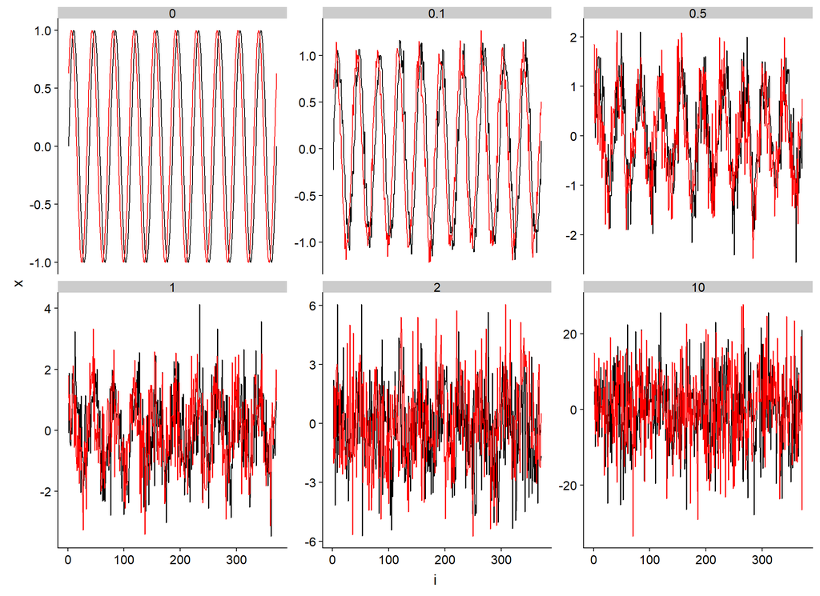

```r
produce_seasonal_series <- function(strength, offset = 4, N = 370) {
    time <- 0:N

    x <- sin(2 * pi * time / 37)            + strength * rnorm(N+1)
    y <- sin(2 * pi * (time + offset) / 37) + strength * rnorm(N+1)

    data_tbl <- tibble(
        i = seq_along(time)
       ,x = x
       ,y = y
    )

    return(data_tbl)
}

gen_data_tbl <- tibble(strength = c(0, 0.1, 0.5, 1, 2, 10)) %>%
    mutate(data = map(strength, produce_seasonal_series)) %>%
    unnest()

ggplot(gen_data_tbl) +
    geom_line(aes(x = i, y = x)) +
    geom_line(aes(x = i, y = y), colour = 'red') +
    facet_wrap(~ strength, ncol = 3, scale = 'free_y')
```

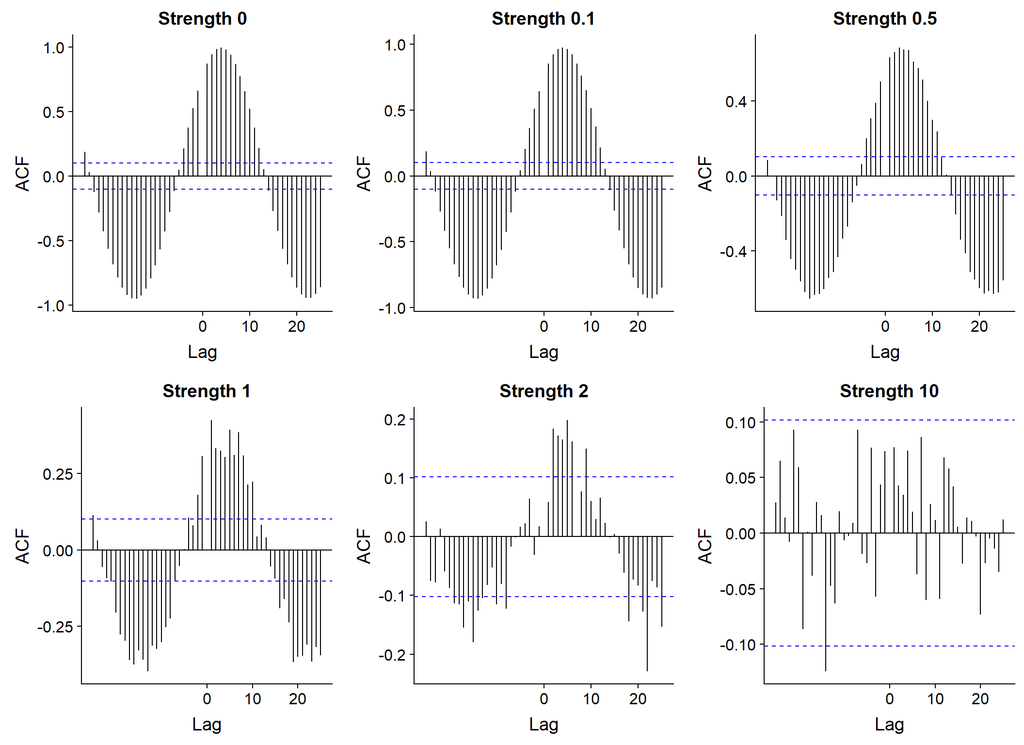

```r
create_ccf_plot <- function(ccf_data, strength) {
    autoplot(ccf_data) +
        ggtitle(paste('Strength', strength))
}

gen_data_tbl %>%
    group_by(strength) %>%
    summarise(ccf_data = list(Ccf(x, y, plot = FALSE))) %>%
    mutate(ccf_plot = map2(ccf_data, strength, create_ccf_plot)) %>%
    pull(ccf_plot) %>%
    plot_grid(plotlist = ., ncol = 3)
```

# 6 Basic Forecasting

The basic task of forecasting is the prediction of future values for some quantity.

One effective method of forecasting is to find a related variable whose value leads it by one or more timesteps. This related variable is often called a *leading indicator*.

A good example of a leading indicator is the ADP numbers in the US. ADP is the main provider of payroll software in the US, and it releases information in advance of US Unemployment statistics. Economic and financial analysts pay close attention to this quantity as it is predictive of the unemployment numbers.

In quantitative trading, one of the first popular and profitable uses of statistical and time series analysis was in *pairs trading* - closely related stocks tend to move together and this analysis enabled profitable trades.

So, for any given quantity, the trick is to find a leading variable and this is often unreliable or non-existent. As a result, we start with the task of using univariate analysis to make our predictions.

## 6.1 Forecasting with Linear Models

One possible starting point for forecasting problems is to use a linear model, much like any other predictive modelling with time as an input to the regression. We account for seasonality by using the various calendar labels as additional predictors.

Rather than fit the model on the whole dataset, we use the final year of data as our test dataset.

```r
ap_lm_data_tbl <- airpassengers_tbl %>%
    mutate(month_label = format(month, '%m')
          ,year_num    = year(month)
           )

ap_train_tbl <- ap_lm_data_tbl %>% filter(year_num != 1960)
ap_test_tbl  <- ap_lm_data_tbl %>% filter(year_num == 1960)
```

### 6.1.1 Simple Linear Model

We now fit a model.

```r
ap_base_lm <- lm(value ~ 0 + month_label + year_num, data = ap_train_tbl)

ap_base_lm %>% glance()
```

```
## # A tibble: 1 x 11
##   r.squared adj.r.squared sigma statistic   p.value    df logLik   AIC   BIC
##       <dbl>         <dbl> <dbl>     <dbl>     <dbl> <int>  <dbl> <dbl> <dbl>
## 1     0.994         0.993  23.5     1459. 1.60e-124    13  -597. 1223. 1263.
## # ... with 2 more variables: deviance <dbl>, df.residual <int>
```

```r
ap_base_lm %>% tidy()
```

```
## # A tibble: 13 x 5
##    term          estimate std.error statistic  p.value
##    <chr>            <dbl>     <dbl>     <dbl>    <dbl>
##  1 month_label01 -59991.   1267.        -47.4 4.49e-79
##  2 month_label02 -59996.   1267.        -47.4 4.45e-79
##  3 month_label03 -59961.   1267.        -47.3 4.76e-79
##  4 month_label04 -59968.   1267.        -47.3 4.69e-79
##  5 month_label05 -59964.   1267.        -47.3 4.73e-79
##  6 month_label06 -59926.   1267.        -47.3 5.08e-79
##  7 month_label07 -59891.   1267.        -47.3 5.43e-79
##  8 month_label08 -59889.   1267.        -47.3 5.44e-79
##  9 month_label09 -59934.   1267.        -47.3 5.01e-79
## 10 month_label10 -59968.   1267.        -47.3 4.69e-79
## 11 month_label11 -59999.   1267.        -47.4 4.43e-79
## 12 month_label12 -59971.   1267.        -47.4 4.67e-79
## 13 year_num          30.8     0.648      47.5 2.93e-79
```

We now check the fitted values against the observed.

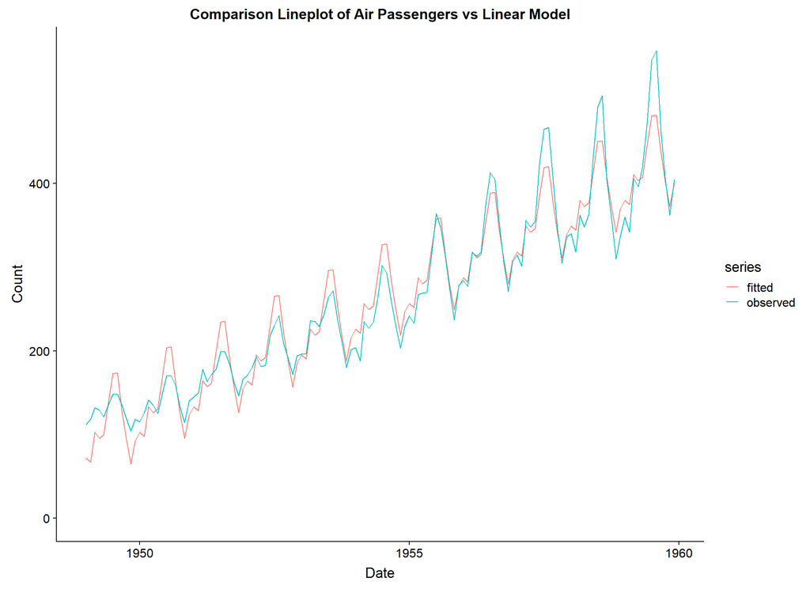

```r
plot_tbl <- ap_base_lm %>%
    augment() %>%
    mutate(month = as.Date(paste(year_num, month_label, '01', sep = '-'))) %>%
    select(month, observed = value, fitted = .fitted) %>%
    gather('series', 'value', -month)

ggplot(plot_tbl) +
    geom_line(aes(x = month, y = value, colour = series)) +
    expand_limits(y = 0) +
    xlab("Date") +
    ylab("Count") +
    ggtitle("Comparison Lineplot of Air Passengers vs Linear Model")
```

We see that the additive model here may be less appropriate as a multiplicative model as our linear model over-estimates early values and then under-estimates towards the end of the series.

We expect this will continue when we try the model with the test data.

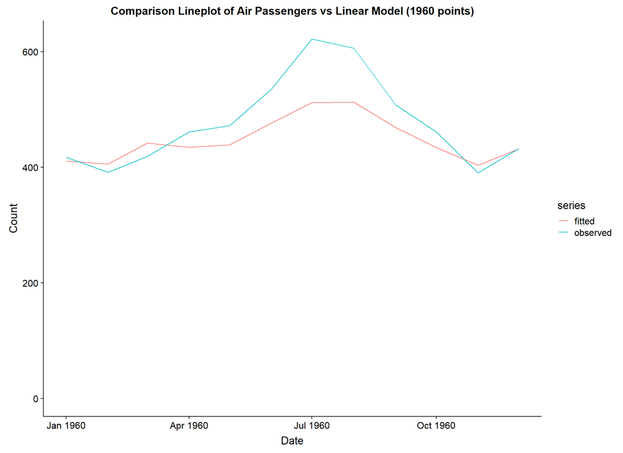

```r
plot_tbl <- ap_base_lm %>%
    augment(newdata = ap_test_tbl) %>%
    mutate(month = as.Date(paste(year_num, month_label, '01', sep = '-'))) %>%
    select(month, observed = value, fitted = .fitted) %>%
    gather('series', 'value', -month)

ggplot(plot_tbl) +
    geom_line(aes(x = month, y = value, colour = series)) +
    expand_limits(y = 0) +
    xlab("Date") +
    ylab("Count") +
    ggtitle("Comparison Lineplot of Air Passengers vs Linear Model (1960 points)")
```

### 6.1.2 Poisson Model

A more appropriate model may be to fit the Poisson model.

```r
ap_base_glm <- glm(value ~ 0 + month_label + year_num
                  ,data   = ap_train_tbl
                  ,family = poisson)

ap_base_glm %>% glance()
```

```
## # A tibble: 1 x 7
##   null.deviance df.null logLik   AIC   BIC deviance df.residual
##           <dbl>   <int>  <dbl> <dbl> <dbl>    <dbl>       <int>
## 1       322545.     132  -532. 1091. 1128.     97.6         119
```

```r
ap_base_glm %>% tidy()
```

```
## # A tibble: 13 x 5
##    term          estimate std.error statistic p.value
##    <chr>            <dbl>     <dbl>     <dbl>   <dbl>
##  1 month_label01 -231.      3.47        -66.5       0
##  2 month_label02 -231.      3.47        -66.5       0
##  3 month_label03 -231.      3.47        -66.5       0
##  4 month_label04 -231.      3.47        -66.5       0
##  5 month_label05 -231.      3.47        -66.5       0
##  6 month_label06 -231.      3.47        -66.5       0
##  7 month_label07 -230.      3.47        -66.4       0
##  8 month_label08 -230.      3.47        -66.4       0
##  9 month_label09 -231.      3.47        -66.5       0
## 10 month_label10 -231.      3.47        -66.5       0
## 11 month_label11 -231.      3.47        -66.5       0
## 12 month_label12 -231.      3.47        -66.5       0
## 13 year_num         0.121   0.00177      68.1       0
```

We now check the fitted values against the observed.

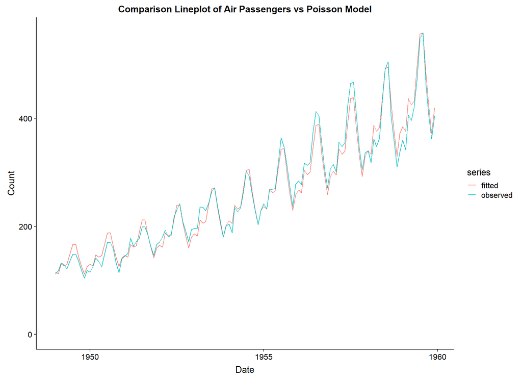

```r
plot_tbl <- ap_base_glm %>%
    augment(type.predict = 'response') %>%
    mutate(month = as.Date(paste(year_num, month_label, '01', sep = '-'))) %>%
    select(month, observed = value, fitted = .fitted) %>%
    gather('series', 'value', -month)

ggplot(plot_tbl) +
    geom_line(aes(x = month, y = value, colour = series)) +
    expand_limits(y = 0) +
    xlab("Date") +
    ylab("Count") +
    ggtitle("Comparison Lineplot of Air Passengers vs Poisson Model")
```

We see that a Poisson model does a better job of capturing the magnitude of the values throughout the series. We hope this means the 1960 data points are better matched also.

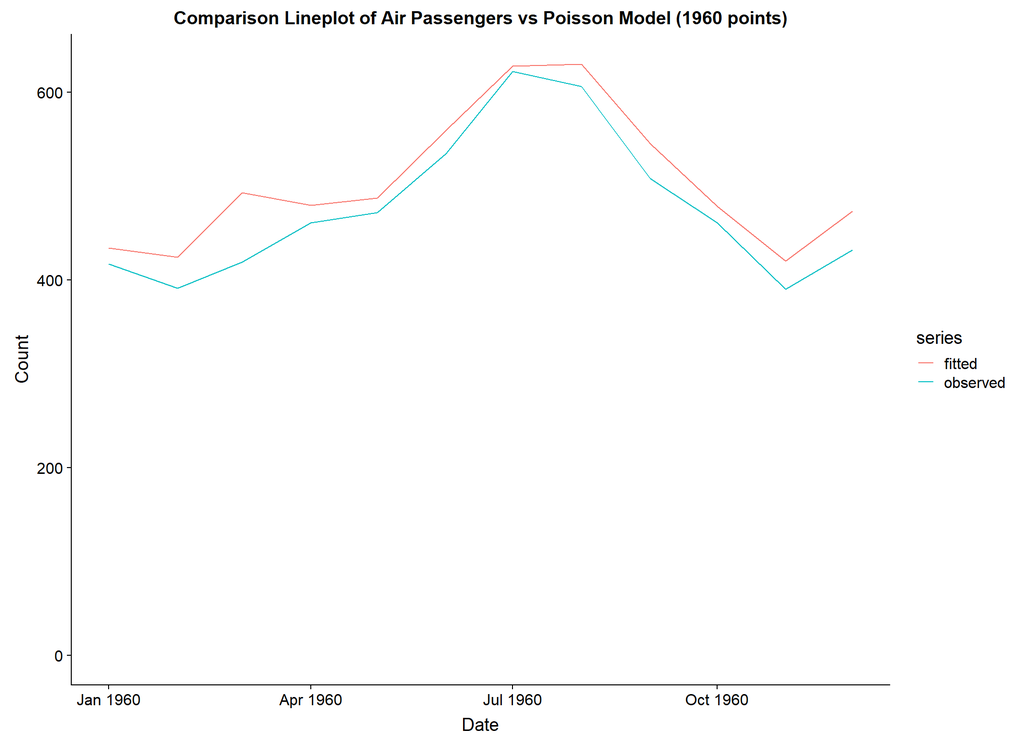

```r
plot_tbl <- ap_base_glm %>%
    augment(newdata = ap_test_tbl, type.predict = 'response') %>%
    mutate(month = as.Date(paste(year_num, month_label, '01', sep = '-'))) %>%
    select(month, observed = value, fitted = .fitted) %>%
    gather('series', 'value', -month)

ggplot(plot_tbl) +
    geom_line(aes(x = month, y = value, colour = series)) +
    expand_limits(y = 0) +
    xlab("Date") +
    ylab("Count") +
    ggtitle("Comparison Lineplot of Air Passengers vs Poisson Model (1960 points)")
```

## 6.2 Time Series Forecasting

Our main objective in forecasting is to estimate the value of a future quantity, $x_{n+k}$, given past values ${x_1, x_2, ..., x_n}$. We assume no seasonal or trend effects, or that such effects are removed from the data.

We assume that the underlying mean of the data is $\mu_t$, and that the value $x_t$ changes from timestep to timestep, but this change is random.

Our model can be expressed as

$$x_t = \mu_t + w_t,$$

where

$$\begin{eqnarray*}
\mu_t &=& \text{non-stationary mean of the process at time } t \\
w_t &\sim& \mathcal{N}(0, \sigma) \text{ (i.i.d)}
\end{eqnarray*}$$

### 6.2.1 EWMA Models

We let $a_t$ be our estimate of $\mu_t$, and can define the *exponentially-weighted moving average (EWMA)*, $a_t$ to be

$$a_t = \alpha x_t + (1 - \alpha) \, a_{t-1}, \;\;\; 0 \leq \alpha \leq 1.$$

The value of $\alpha$ controls the amount of smoothing, as is referred to as the *smoothing parameter*.

The main package we use for forecasting in R is the `forecast` package, created by Rob Hyndman. `forecast` contains a convenient framework for performing most of the task required for time series forecast. We then use the `sweep` package to bring the outputs into a tidy format where appropriate.

```
\worksheetexercise
Load the data in the \texttt{motororg.dat} file. This is a count of
complaints received on a monthly basis by a motoring organisation from
1996 to 1999. Create an appropriate time series from this data. Plot
the data, checking it for trends or seasonality.

\worksheetexercise
Using the function \texttt{HoltWinters()}, with the additional
parameters set to zero, create the EWMA of the data, allowing the
function itself to choose the optimal value of $\alpha$. Investigate
and visualise the output, comparing it to the original time series.

\worksheetexercise
Specifying values of $\alpha$ of 0.2 and 0.9, create new versions of
the EWMA and compare them with previous fits of the EWMA.
```

### 6.2.2 Holt-Winters Model

The Holt-Winters method generalises this concept, allowing for trends and seasonal effects. The equations that govern this model for seasonal period, $p$, are given by

$$\begin{eqnarray*}
a_t &=& \alpha (x_t - s_{t-p}) + (1 - \alpha) (a_{t-1} - b_{t-1}),\\
b_t &=& \beta (a_t - a_{t-1}) + (1 - \beta) b_{t-1},\\
s_t &=& \gamma (x_t - a_t) + (1 - \gamma) s_{t-p},
\end{eqnarray*}$$

where

$$\begin{eqnarray*}
a_t && \text{is the estimated level at time $t$},\\
b_t && \text{is the estimated slope at time $t$},\\
s_t && \text{is the estimated seasonal effect at time $t$},\\
\alpha, \beta, \gamma && \text{are smoothing parameters}
\end{eqnarray*}$$

```
\worksheetexercise
Fit the Holt-Winters parameters to the air passenger data and check
the fit. Visualise the raw time-series against the fitted data.

\worksheetexercise
Predict data ahead for four years and visualise this data. How
reliable are these forecasts do you think?
```

# 7 AR, MA and ARMA Models

$$x_t = x_{t-1} + w_t,$$

where $w_t$ is a white-noise series.

```
\worksheetexercise
Generate a white noise series using \texttt{rnorm()}, with an initial
value, $w_0 = 1$. and length 100. Plot the output, and investigate its
correlogram.

\worksheetexercise
Generate a random walk time series with initial value $x_0 = 1$ and
length 100. Plot its output and investigate its correlogram.

\worksheetexercise
Think about how you might create a random walk with an underlying
drift?
```

## 7.1 Autoregressive Process - AR(p)

$$\begin{equation}
x_t = \sum^p_{i=1} \alpha_i x_{t-i} + w_t,
\end{equation}$$

where $w_t$ is a white-noise process and the $\alpha_p \neq 0$ for an order-$p$ process.

```
\worksheetexercise
Generate data for an AR(1) model with $\alpha = 0.5$ and initial value
$x_1 = 1$. Plot the data and investigate its correlogram. Does this
time series appear to be stationary? The R function
\texttt{arima.sim()} can be used for this.

\worksheetexercise
Generate data for an AR(2) model with $\alpha_1 = 1$ and
$\alpha_2 = -0.25$ and initial value $x_1 = 1$, $x_2 = 1$. Plot the
data and investigate its correlogram. Does this time series appear to
be stationary?

\worksheetexercise
Generate data for an AR(2) model with $\alpha_1 = 0.5$ and
$\alpha_2 = 0.5$ and initial value $x_1 = 1$, $x_2 = 1$.

\worksheetexercise
Fit the time-series you generated above to an autoregressive model
using the function \texttt{ar()}. How do the fitted parameters match
the values you used?
```

## 7.2 Moving Average Process - MA(q)

A moving average (MA) process of order $q$ is a linear combination of the current white noise term and the $q$ most recent past white noise terms,

$$\begin{equation}
x_t = w_t + \sum^q_{i=1} \beta_i w_{t - i}
\end{equation}$$

where $w_t$ is a white-noise process with mean 0 and variance $\sigma^2$.

```
\worksheetexercise
Generate data for an MA(1) model with $\beta = 0.5$ and initial value
$x_1 = 1$. Plot the data and investigate its correlogram. Does this
time series appear to be stationary?

\worksheetexercise
Generate data for an MA(2) model with $\beta_1 = 1$ and
$\beta_2 = -0.25$ and initial values $x_1 = 1$, $x_2 = 2$. Plot the
data and investigate its correlogram. Does this time series appear to
be stationary?

\worksheetexercise
Generate data for an MA(2) model with $\beta_1 = 0.5$ and
$\beta_2 = 0.5$ and initial values $x_1 = 1$, $x_2 = 1$.

\worksheetexercise
Fit the time-series you generated above to a moving-average model
using the function \texttt{arima()}. How do the fitted parameters
match the values you used?

\worksheetexercise
Compare the AR and MA models to one another.
```

## 7.3 ARMA and ARIMA Models

Now suppose we combine the ideas of autoregressive and moving average models together. A time series follows an *autoregressive moving average (ARMA)* process of order $(p, q)$ when

$$x_t = \sum_{i=1}^p \alpha_i x_{t-i} + w_t + \sum_{j=1}^q \beta_j w_{t-j}$$

where $w_t$ is white noise.

```
\worksheetexercise
Using the R function \texttt{arima.sim()}, create an ARMA(1,1)
time-series of length 1000 with $\alpha = -0.6$, and
$\beta = 0.5$. Plot this time series and check its ACF. Is this
correct?

\worksheetexercise
Using \texttt{arima()}, fit your generated time series to an
$\text{ARMA}(1,1)$ model and compare the fitted output to the values
you have set.

\worksheetexercise
Repeat the above exercises, but for an $\text{ARMA}(2, 2)$ model with
$\alpha_1 = 0.2$, $\alpha_2 = -0.5$, $\beta_1 = -0.1$ and
$\beta_2 = 0.3$.

\worksheetexercise
Investigate the effect of the parameters $p$ and $q$ by generating the
various combinations of the $\text{ARMA}(p, q)$ models but using the
same set of innovations in each case.\\
\textbf{HINT:} \texttt{arima.sim()} has a parameter \texttt{innov = ...}
that allows you to pass in a set of innovations into the ARMA process.

\worksheetexercise
Load in the GBP/NZD currency pair data from the file
\texttt{pound\_nz.dat}, and create a time-series from this. The data is
quarterly, and starts in Q1 1991.

\worksheetexercise
Fit the data GBP/NZD to an $\text{MA}(1)$, an $\text{AR}(1)$ and an
$\text{ARMA}(1, 1)$ process. Which of the above models does the best
job at fitting the data?
```

### 7.3.1 Fitting ARMA Models

It may be becoming quickly apparent that the choice of parameter count is non-trivial, and some kind of systematic approach would be desirable.

One such method for choosing the optimal number of parameters is to fit multiple options and choose the best one, using a metric known as the *Akaike Information Criterion (AIC)*. The AIC is defined to be

$$\text{AIC} = -2 \times \text{loglikelihood of fit} + 2 \times \text{parameter count},$$

so that it balances the better fitting of parameters while penalising using too many parameters to fit.

```
\worksheetexercise
Use the R function \texttt{AIC} to calculate the AIC of the three
models above. Which one is the best? Why is this question a trap?

\worksheetexercise
Using all of the various techniques in this workshop, try to model the
electricity time series data from the CBE dataset.
```